# NxtIRF: 2 - Building an Experiment

Alex Chit Hei Wong

2021-02-05

Now that you have built a reference, you can use it to analyse BAM files of aligned RNA-seq data.

First, load the NxtIRF package:

```r
library(NxtIRF)
```

## Download the example dataset

Now, set the working directory to the same working directory so that the previously build reference can be accessed through “./Reference”. Create a directory to place the sample BAM files:

```r
dir.create("bams")      # Create the directory to contain the BAM files
download_NxtIRF_example(destination_dir = "./bams")
```

# Using the Command Line Interface

NxtIRF provides convenience functions to identify all files of certain types inside a parent directory. Here, we will locate all the BAM files in the directory where we just downloaded the sample files:

```r
bamfiles.df = Find_Bams("./bams")
```

bamfiles.df contains a data frame with the first column being the sample names. NxtIRF assumes the files are named by their samples. Sometimes datasets may choose to use the directory names as their sample names. In this case, set “use_subdir = TRUE”

```r
bamfiles.df = Find_Bams("./bams", use_subdir = TRUE)
```

Note that all the sample names are now named by the directory containing the files. In our dataset, we have named the files by their sample names. So lets set “use_subdir = FALSE”

```r
bamfiles.df = Find_Bams("./bams", use_subdir = FALSE).
View(bamfiles.df)   # To view the output of this function in RStudio
```

## Running IRFinder

To run IRFinder, run the following command:

```r
IRFinder(
    bamfiles = bamfiles.df$BAM,
    sample_names = bamfiles.df$sample,
    reference_path = "./Reference",
    output_path = "./IRFinder_Output",
    n_threads = 1
)
```

NxtIRF will create the “IRFinder_Output” and run the IRFinder algorithm to all the provided BAM files using the reference found in the provided directory containing the reference.

For those with multi-core systems, feel free to use multiple threads. NxtIRF will use one core per sample, and processes the samples in parallel until finished.

Be aware however, for typical RNA-seq files containing 100 million reads, NxtIRF typically use 5-12 Gb of RAM per sample.

## Collating the IRFinder output

After the IRFinder run, the data can be collated into an experiment. First, we use another convenience function to assemble a data frame containing the IRFinder output files:

```r
expr.df = Find_IRFinder_Output("./IRFinder_Output")
View(expr.df)
```

Lets look at the newly created data frame. IRFinder generates two files per BAM file processed. The file ending in “.txt.gz” contains the text output of the IR and splice junction quantitation, as well as the QC parameters. Feel free to use gzip, WinRAR, or other utility to decompress and view the output files.

The second file is the COV file. This is a binary file format introduced by NxtIRF to compress data containing read or fragment coverage for each nucleotide in the aligned genome. We will demonstrate this in the Visualisation vignette.

For now, lets run CollateData() to assemble all the output files:

```r
CollateData(
    Experiment = expr.df,
    reference_path = "./Reference",
    output_path = "./NxtIRF_Output",
    IRMode = "SpliceOverMax",       # Use IRMode = "SpliceMax" for legacy IRFinder calculation of IR-Ratio
    low_memory_mode = TRUE,         # Only set to FALSE in large servers with lots of memory
    n_threads = 1
)
```

CollateData creates the “NxtIRF_Output” directory and processes the output path provided by the “expr.df data frame. The IRMode is set to”SpliceOverMax" which uses the new approach to count the total spliced reads associated with each intron, as outlined in my thesis. For those wishing to use the IRFinder default method, set IRMode = “SpliceMax”.

Note that we set `low_memory_mode = TRUE`. This is not so important for small numbers of samples, but is required if running large numbers (more than 16) on a laptop or desktop computer with limited RAM. Low_memory_mode saves the output of every 16 samples to disk to avoid keeping the output of the whole experiment into memory. For servers or computers with ample RAM, feel free to set low_memory_mode = FALSE.

## Assembling the experiment

Now that the IRFinder output has been collated, we are now ready to assemble it. NxtIRF uses the SummarizedExperiment structure to contain the data. It also provides the option to assemble the experiment containing a subset of samples. To do this, we provide a data frame with the first column containing the sample names that we want to assemble. We also should provide some annotation as to which samples belong to which experimental condition. In our example dataset, the “UT” samples are untreated, whereas the “D2” samples have been treated with doxycycline for 2 days. So lets assemble this data frame:

```r
colData = data.frame(sample = expr.df$sample)
colData$Treatment = data.table::tstrsplit(colData$sample, split="_")[[1]]
View(colData)
```

Now, we use `MakeSE()` to assemble the SummarizedExperiment.

```r
se = MakeSE(
    fst_path = "./NxtIRF_Output",
    colData = colData
)
```

## Filtering for expressed events

Note that se contains more than 400k entries of the 6 samples. This is because all the IR and alternative splicing events have been included.

To filter for events in expressed genes and transcripts, we use various expression and QC features. For now, lets use the default filters:

```r
filters = get_default_filters()

se.filtered = se[apply_filters(se, filters),]
```

For more information regarding the filters, consult the documentation via `?runFilter()`

Note that `se.filtered` contains less than 1000 entries. These are all the IR and alternate splicing events that are detected as expressed by the samples. This reduces issues arising from multiple testing corrections.

## Differential Analysis

Now we are ready to perform differential analysis. Run the following command:

```r
res.limma = limma_ASE(
    se = se.filtered,
    test_factor = "Treatment",
    test_nom = "D2",
    test_denom = "UT",
)
```

This command runs differential alternative splicing event (ASE) analysis on the filtered SummarizedExperiment object. We ask this function to contrast between the “D2” and “UT” samples in the “Treatment” field.

Feel free to view the `res.limma` output table to view the results. For more information about this output, refer to `?limma_ASE`

Do not forget to save the results of this data frame. We will save it as a csv file, as shown:

```r
data.table::fwrite(res.limma, file = "res.limma.csv")
```

# Graphics User Interface

The example below runs through all the steps outlined in the command line interface version of the example given above.

Make sure you followed the instruction to download the sample BAM files.

Navigate to the parent directory of the “bams” directory. Start the GUI using the following:

```r
library(NxtIRF)
nxtIRF()
```

[figure not shown]

Title page

## Setting the number of threads

Before we start, select “System” on the left, then select “Single-Thread” to run this example in single-threaded mode

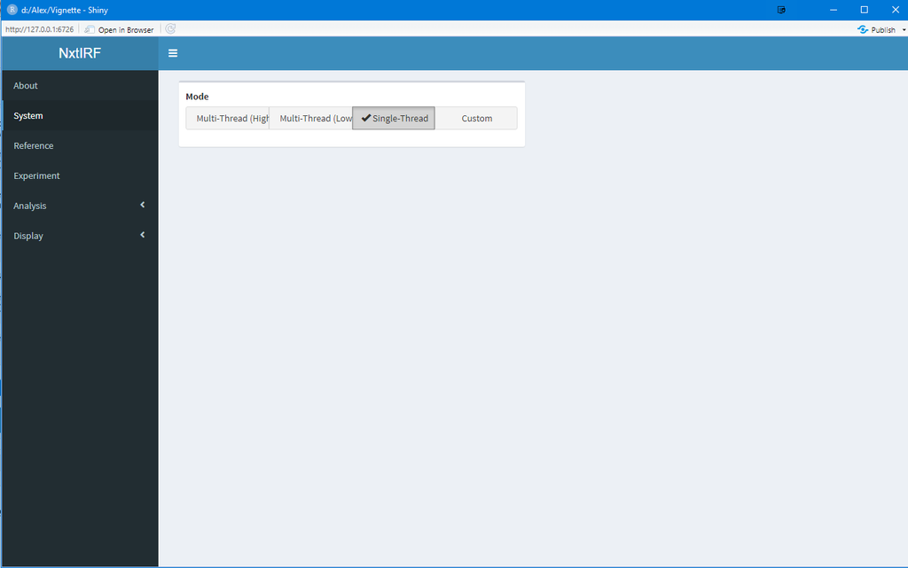

System

## Loading the reference and the BAM files

Next, navigate to the `Experiment` tab:

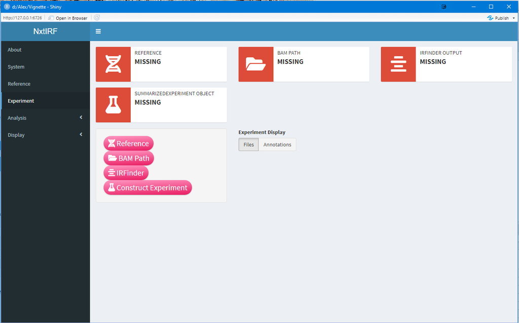

Experiment

Click the pink “Reference” button then click the “Select Reference Path” button. Follow the dialog box to select the reference directory containing the reference we build in the Reference vignette.

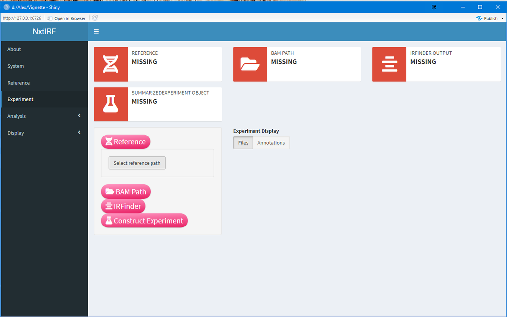

Select Reference Path

If the reference was successfully detected, NxtIRF should look like this, displaying the properties of the reference that is now loaded:

[figure not shown]

Details of the Loaded Reference

Click the pink “Reference” button to close the Reference pop-up. Now click the “BAM Path” button then “Select BAM path” to select the path containing the downloaded sample BAM files:

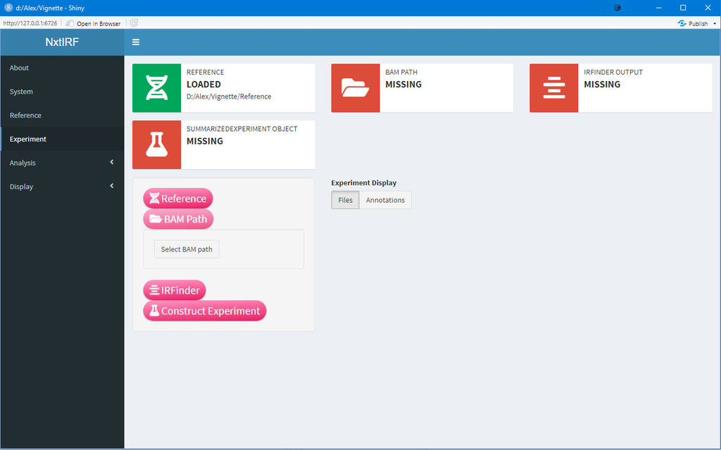

Select BAM Path

After selecting the bams directory, NxtIRF should show a list of sample names and associated BAM files.

[figure not shown]

List of BAM files

Note that NxtIRF detects the sample names from the BAM files. If all the BAM files have the same name, NxtIRF will assume the directory containing the BAM files are named by sample names. If samples have identical names, NxtIRF will not be able to process the files.

## Running IRFinder

First we need to create a directory to contain the IRFinder output. To do this, click the pink “IRFinder” button and choose the IRFinder output path. You may need to create a new directory using the dialog box, similar to how you created the “Reference” directory in the previous vignette.

After you have done this, you are ready to run IRFinder. First drag with the mouse to select the cells containing the file paths of the BAM files. Then click the “Run IRFinder” button.

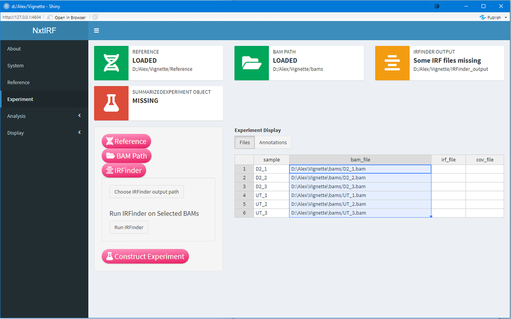

Selecting BAM files to run IRFinder

A warning popup will ask you to confirm whether to continue running IRFinder. This is to make sure those planning to run multiple samples on large servers to set multi-threading options. As we are running small sample files, click the red “Run IRFinder” button to continue

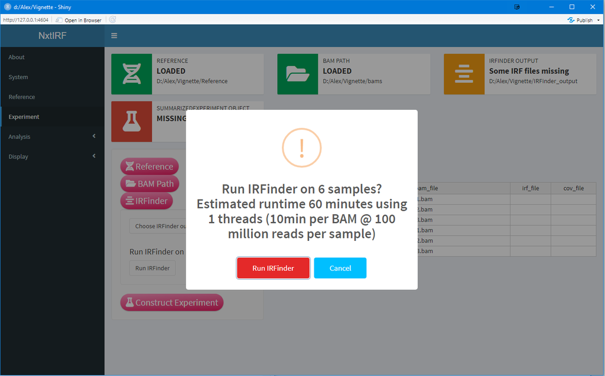

Confirm to run IRFinder

When IRFinder is done, a notification popup will show:

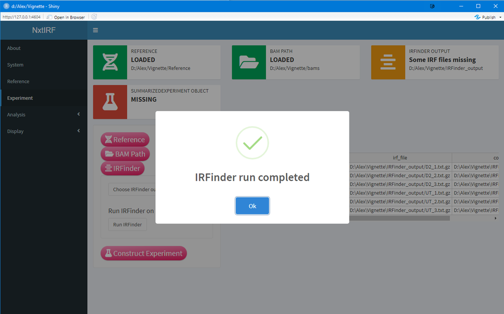

IRFinder is complete

Close the IRFinder tab by clicking its pink button.

## Collating IRFinder output

To collate the IRFinder output into one experiment, first we need to assign the sample annotations. Click the “Annotations” tab above the sample table. This switches to a different table where you can set sample designations. A box on the left side of the table will show providing functions to add or remove columns from this new table.

Type in the name of a new column we wish to add: “Treatment”, click “character” to tell NxtIRF the data included here includes letters and numbers, and click “Add” to add this column.

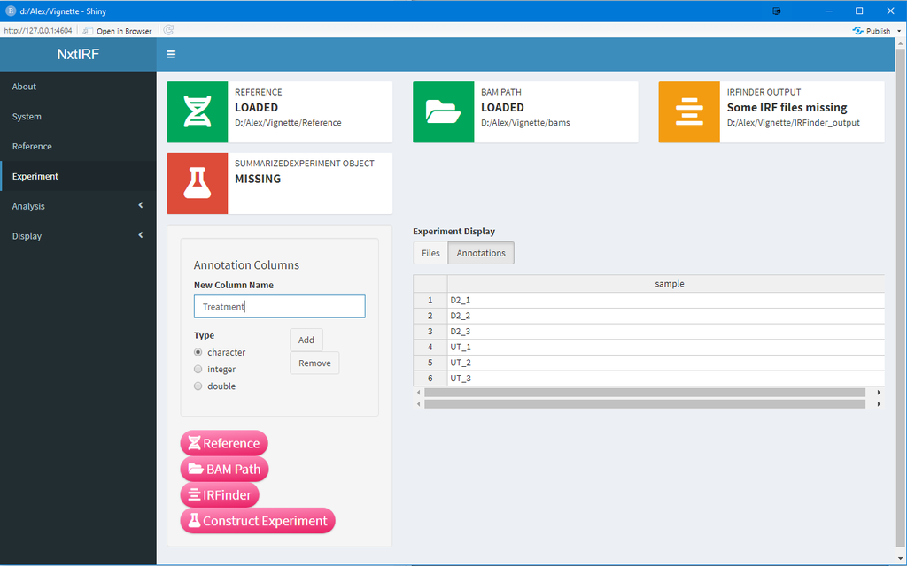

Add an annotation column

Once you have done this, assign the treatment annotations to the samples. Write “D2” in the first 3 cells, and “UT” in the last 3. This is a rHandsOnTable object that performs basic functions similar to Excel.

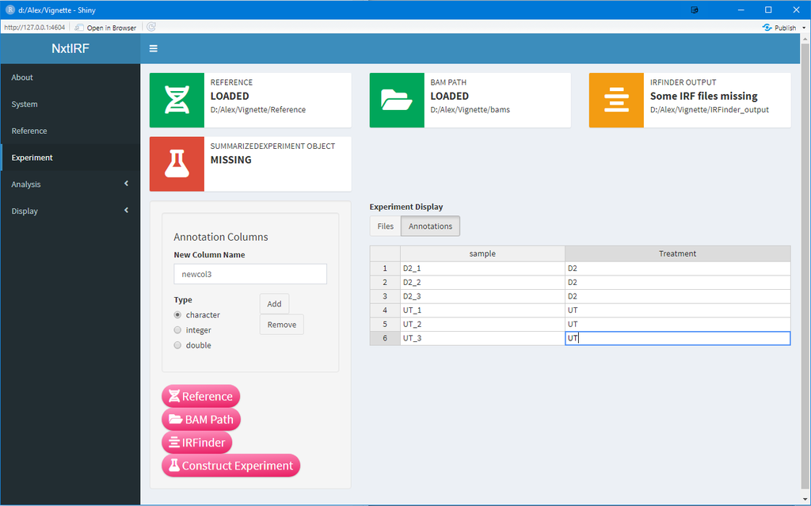

Annotate your samples

Once this is done, click the “Files” button above the table to close the “Annotation columns” dialog box. Click the “Construct Experiment” pink button. Then click “Choose NxtIRF FST output path” and create a new directory to place the output for the collated data. Then run CollateData() by clicking “Compile NxtIRF FST files”.

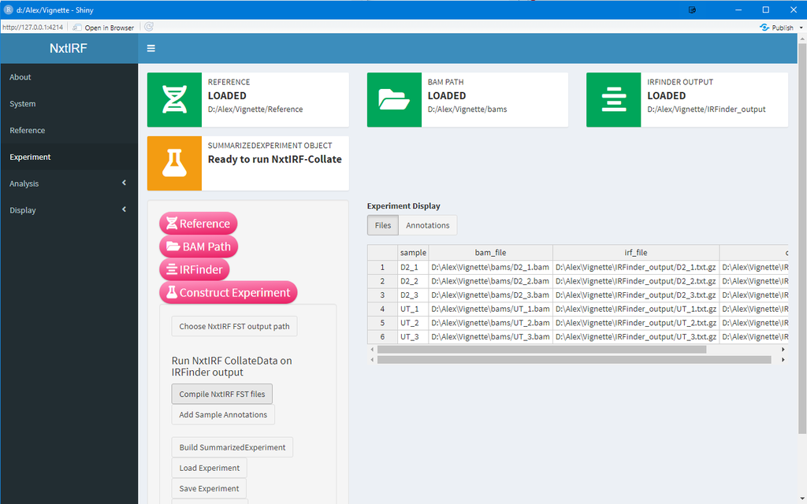

Collating the IRFinder output

A progress window on the bottom right corner will display the progress as the data is compiled. Once this is finished, a popup notification will show.

[figure not shown]

NxtIRF collation is done!

## Loading the SummarizedExperiment object

Congratulations, you have run IRFinder and collated the output. Now all you need to do is load the data into memory by clicking “Build SummarizedExperiment”. When this is done, all 4 status boxes will turn green.

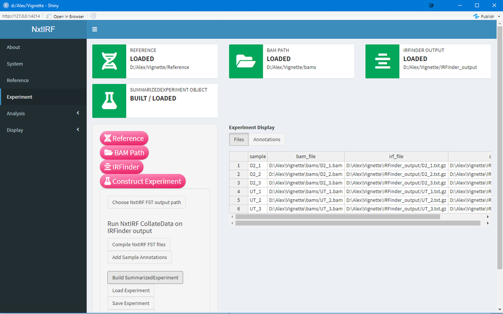

Load the SummarizedExperiment

## Viewing QC Parameters

Now click the Analysis tab in the navigation panel, then click Experiment QC. A summary table will show the QC parameters for each sample.

[figure not shown]

QC tab

We can visually compare QC parameters. For example, set the Mode drop-down box to “Graphs”, then set the “X axis” to “depth”. A plotly graph shows the sequencing depth of each sample.

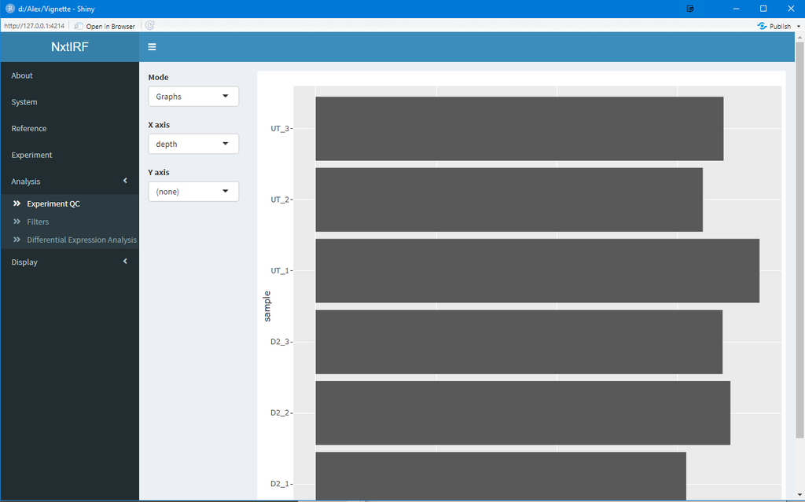

Read depth per sample

We can also compare one QC parameter against another. For example, we can compare intergenic read fraction with IRBurden (a parameter that measures global IR). Set the X and Y axes to “Intergenic_Fraction” and “IRBurden_clean”.

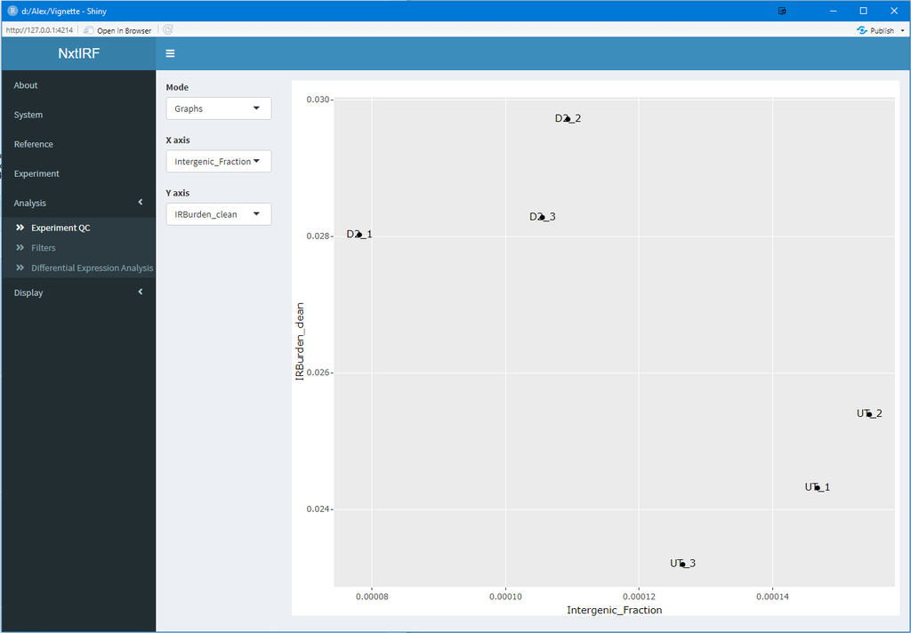

Comparisons between two QC parameters

## Filtering IR and Alternative Splicing events

To filter for IR and alternatively splicing events for expressed transcripts, head to the “Filters” tab in the Analysis navigation section:

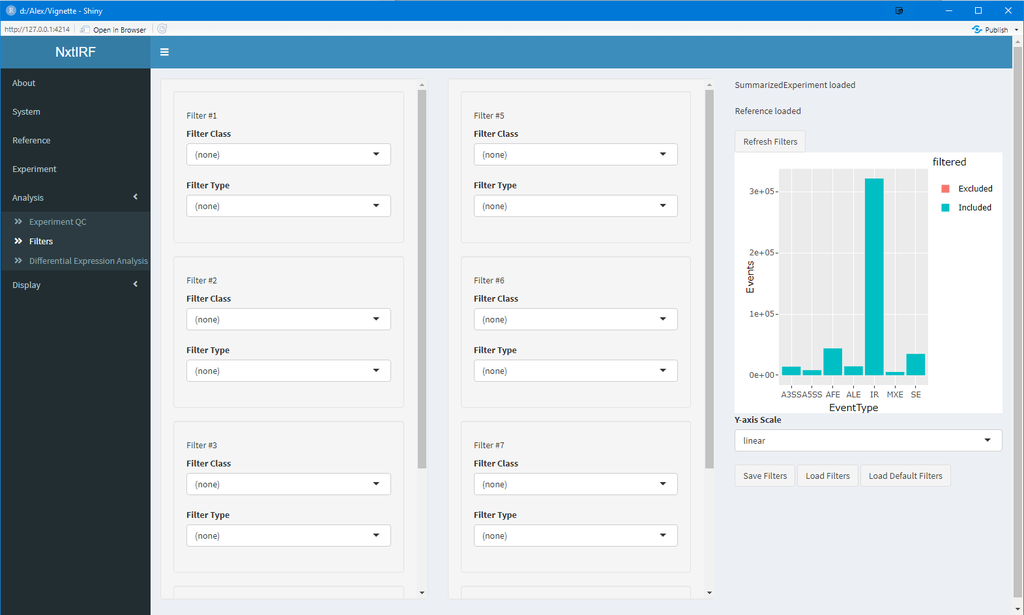

Filters tab

This displays a list of empty filters. As a full discussion of filters is beyond the scope of this vignette, lets load the default filters using the “Load Default Filters” button on the bottom right. Then, click “Refresh Filters” above the column graph:

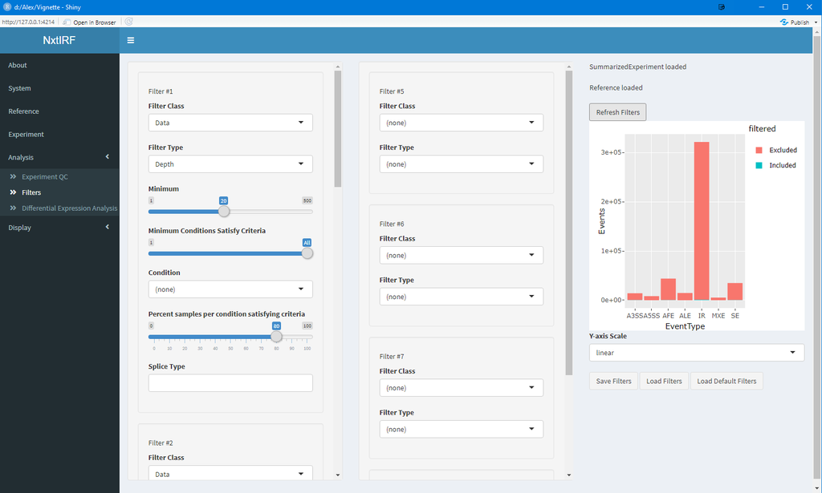

Loading and running default filters

Now, it looks like all the events have been filtered out because all the columns are now red. However, this is not true because the sample BAM files map to a very small region of the genome, so most events are expected to be filtered out. To view the included events, set the Y scale to log instead of linear, using the drop-down box located below the graph:

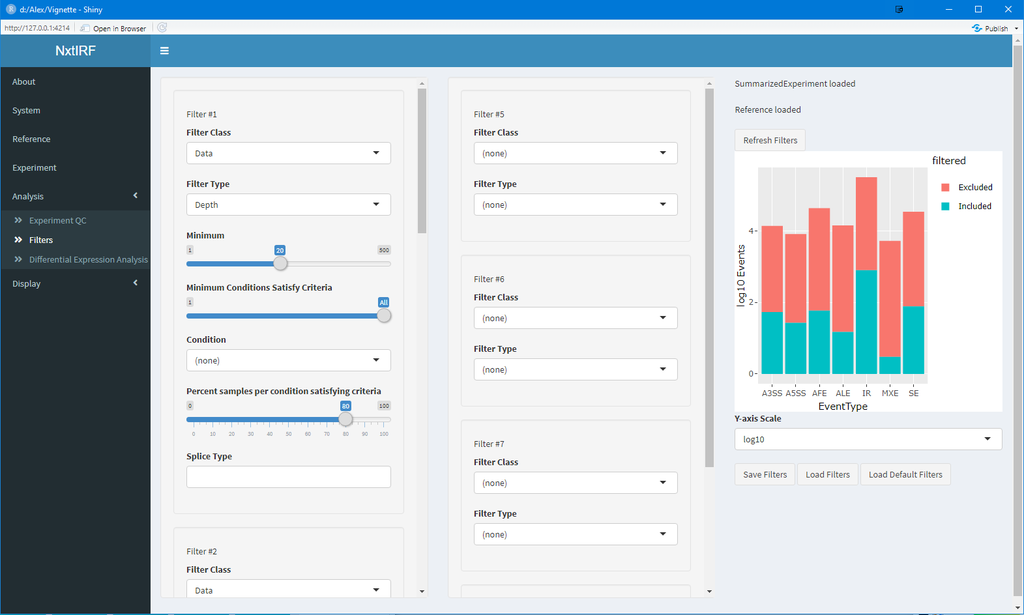

Selecing log10 scale

Feel free to hover the mouse over the columns. The values are given in log-10 scale for Included events. Note that hovering over the red bars will give the log10(Excluded) - log10(Included) values, rather than the number of excluded events.

## Differential Alternative Splicing Expression Analysis

We are finally ready to perform differential analysis. Click the “Differential Expression Analysis” panel from the Analysis drop-down bar.

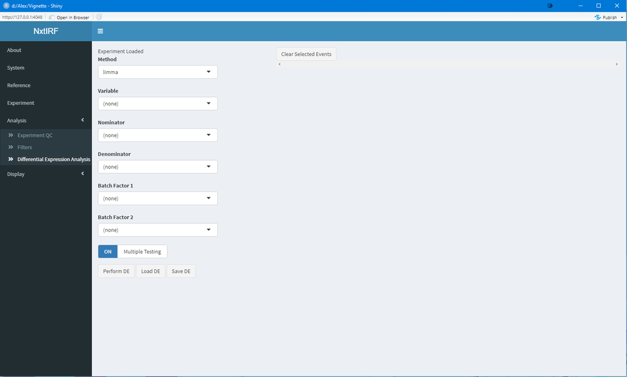

Differential Expression Analysis tab

For the purposes of this vignette we will use Limma (although using DESeq2 also works). Change the “Variable” value to “Treatment” to indicate we will perform differential analysis across treatment conditions. For the nominator, choose “D2”, and use “UT” for the denominator. This means that positive log-fold changes indicate IR is higher in “D2” versus “UT”, and vice versa for negative log-fold values. Leave the “Batch1” and “Batch2” unassigned. The “Multiple Testing” switch should be set to true so NxtIRF will sort results by adjusted P values. Your settings should like below:

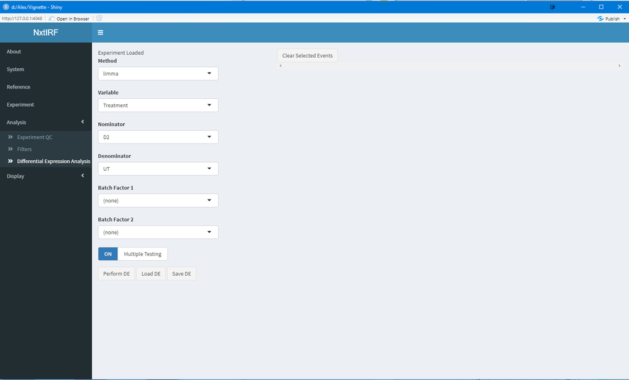

Settings to perform differential analysis on D2 vs UT samples

Click “Perform DE” to run the differential analysis. Once this is performed, a results table of the differential analysis will be displayed. For more information regarding the columns, refer to `?limma_ASE`

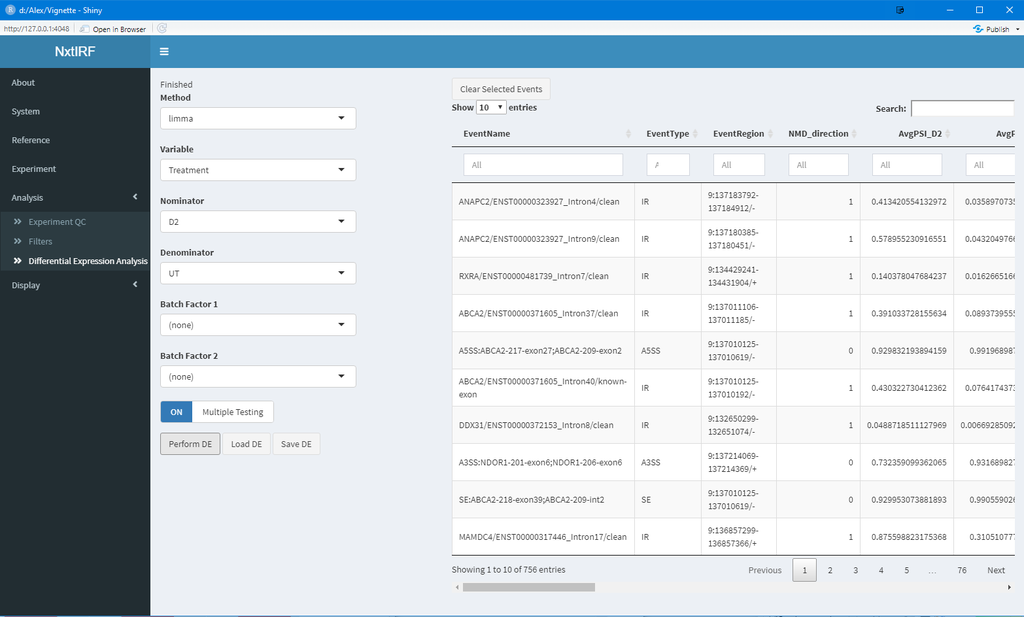

Differential analysis results

To save this table for later use (including visualisation), click “Save DE” and give a file name for the results. In this vignette, we name this as “limma_results.Rds” for use in the next vignette which shows the interactive visualisation tools of NxtIRF. See you there!